# Acoustic_2019_Explore

Sean Dimoff

October 9, 2019

**Exploratory Plots for 2017-2018 Acoustic/Fish Data**

**Purpose** To explore the Acoustic data gathered in 2017 and 2018 to expose important trends between sites, diurnal patterns, fish abundance, lunar phase, and coral reef acoustics.

# Acoustics

**Acoustics Breakdown** All acoustic metrics (SPL and ACI) are broken down into 3 frequency bands: Broadband (All frequencies), High Frequency (Frequencies between 1 kHz - 22 kHz), and Mid Frequency (Frequencies between 160 Hz and 1 kHz)

*Note* 2017 had a 10 minute duty cycle with 5 minutes recording while 2018 had a 15 minute duty cycle with 5 minutes recording, so the number of files averages differs between years

## SPL (Hourly Averages)

### Broadband

Broadband SPL averaged by hour across all days

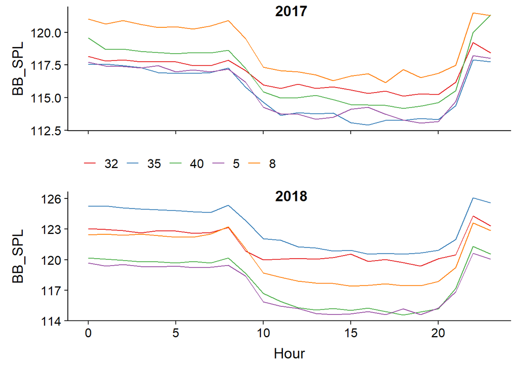

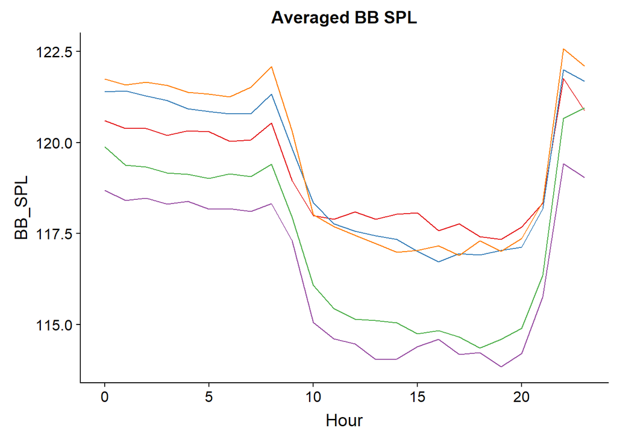

### High Frequency

High Frequency SPL averaged by hour across all days

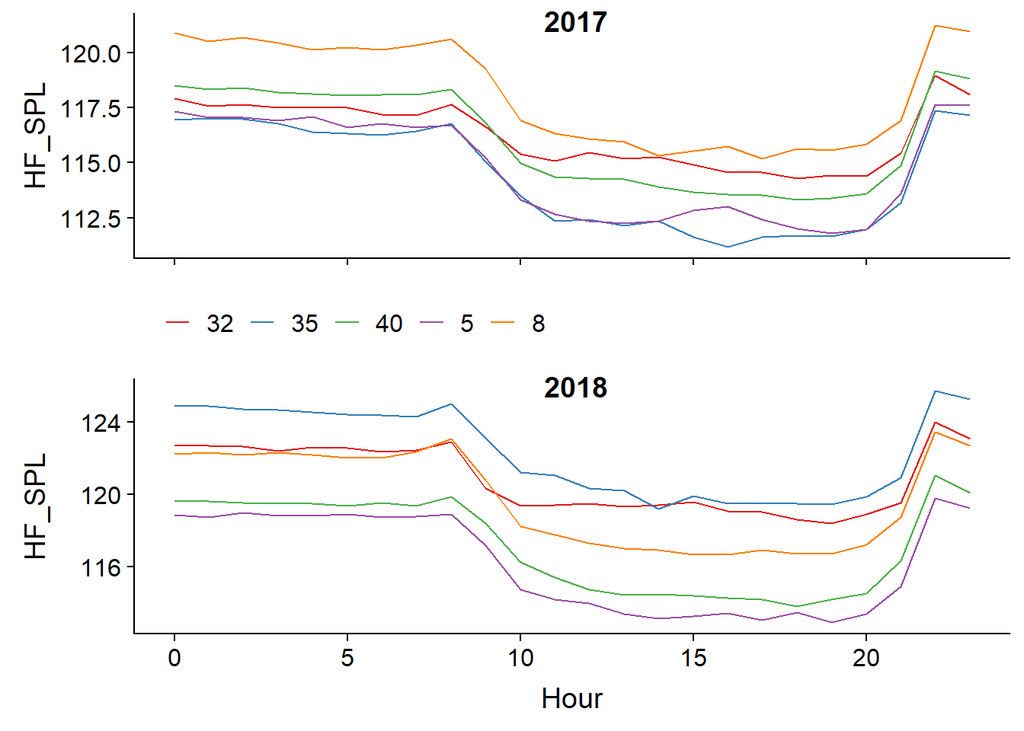

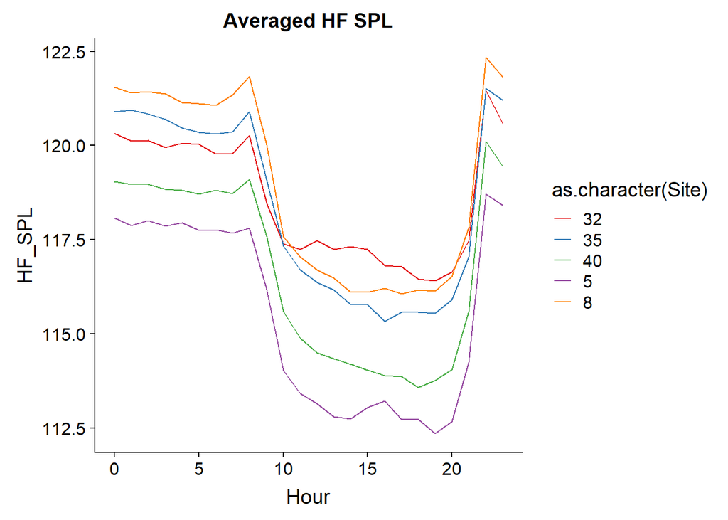

### Mid Frequency

Mid Frequency SPL averaged by hour across all days

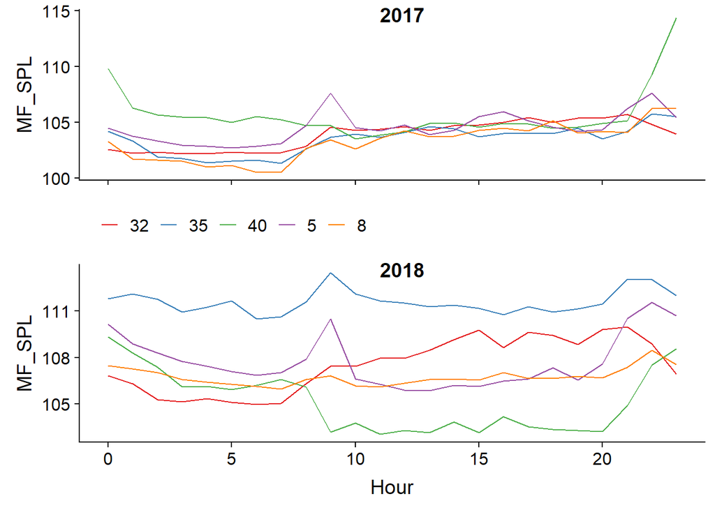

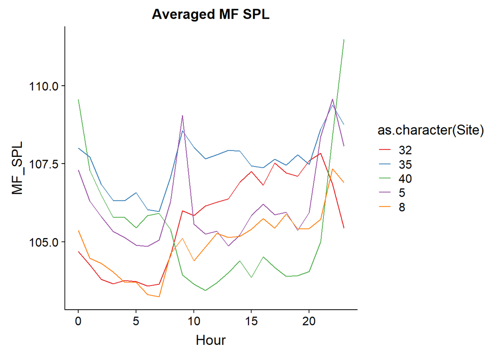

### Boxplots

Distribution of SPL at all frequencies and sites - averaged by hour

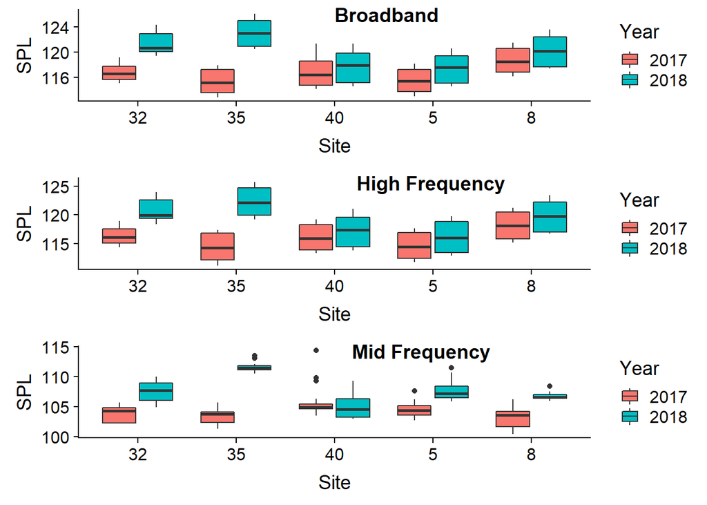

## ACI (Hourly Averages)

### Broadband

Broadband ACI averaged by hour across all days

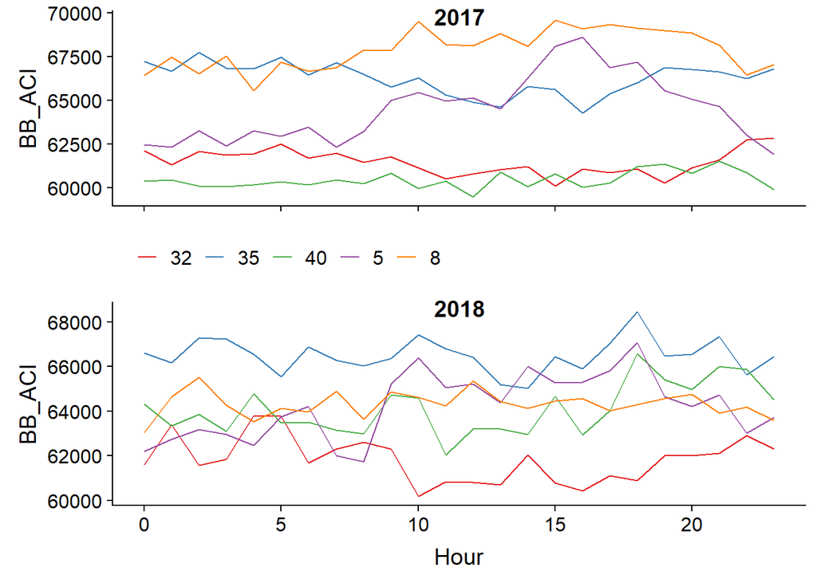

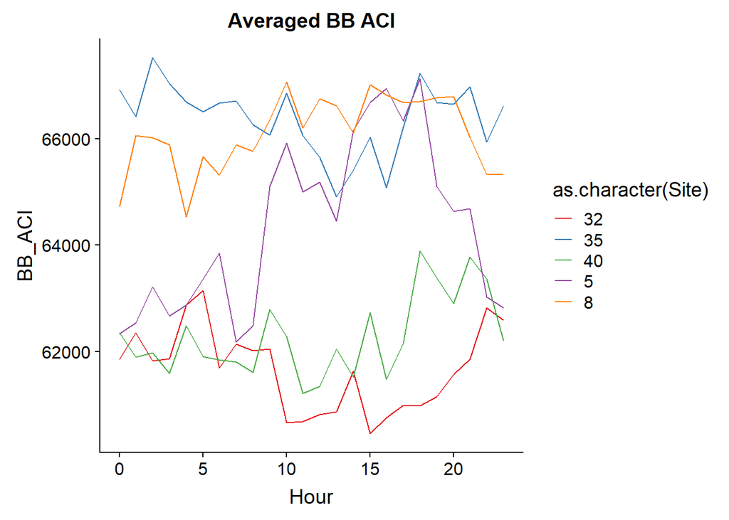

### High Frequency

High Frequency ACI averaged by hour across all days

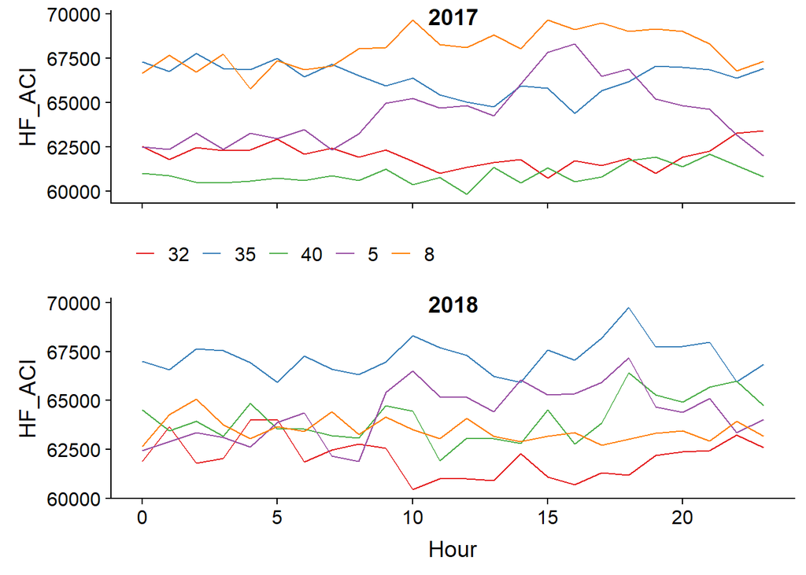

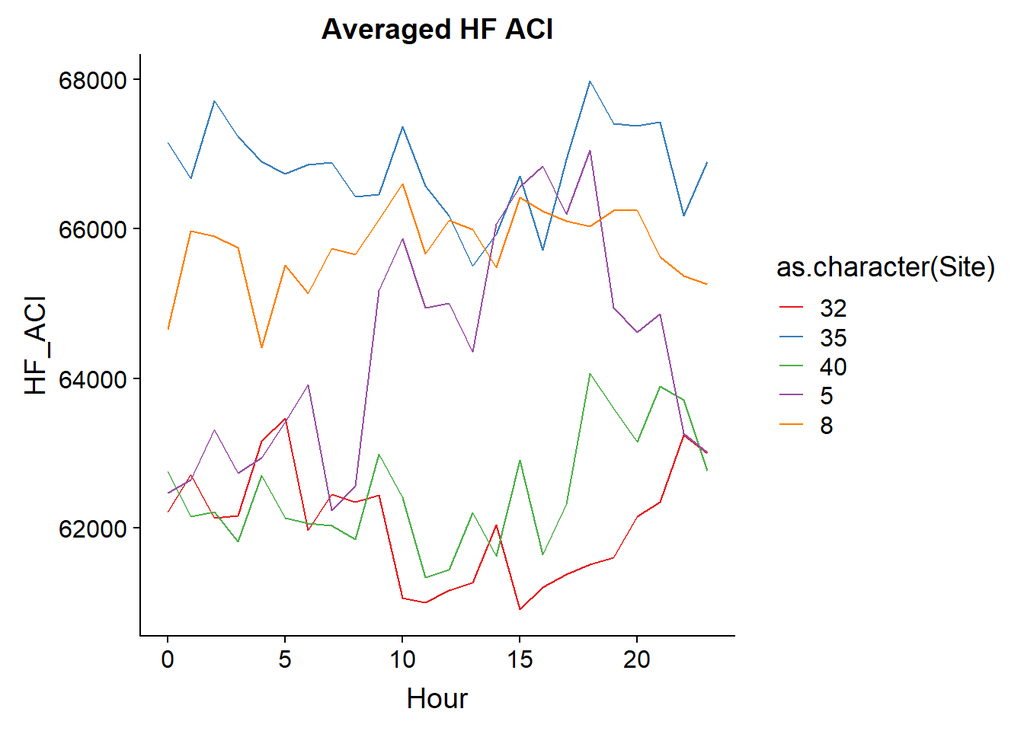

### Mid Frequency

Mid Frequency ACI averaged by hour across all days

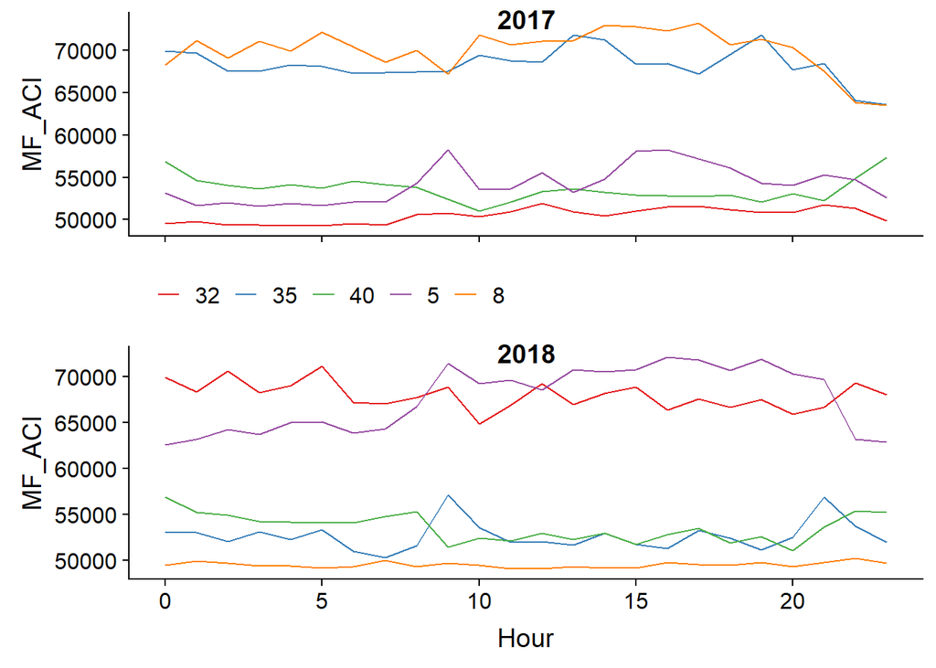

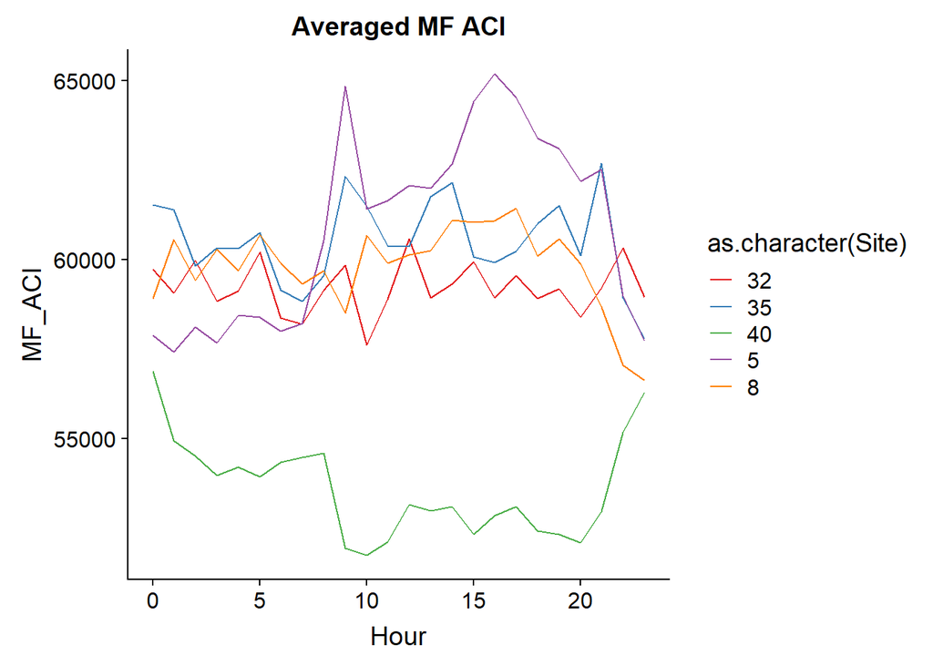

### Boxplots

Distribution of ACI at all frequencies and sites - averaged by hour

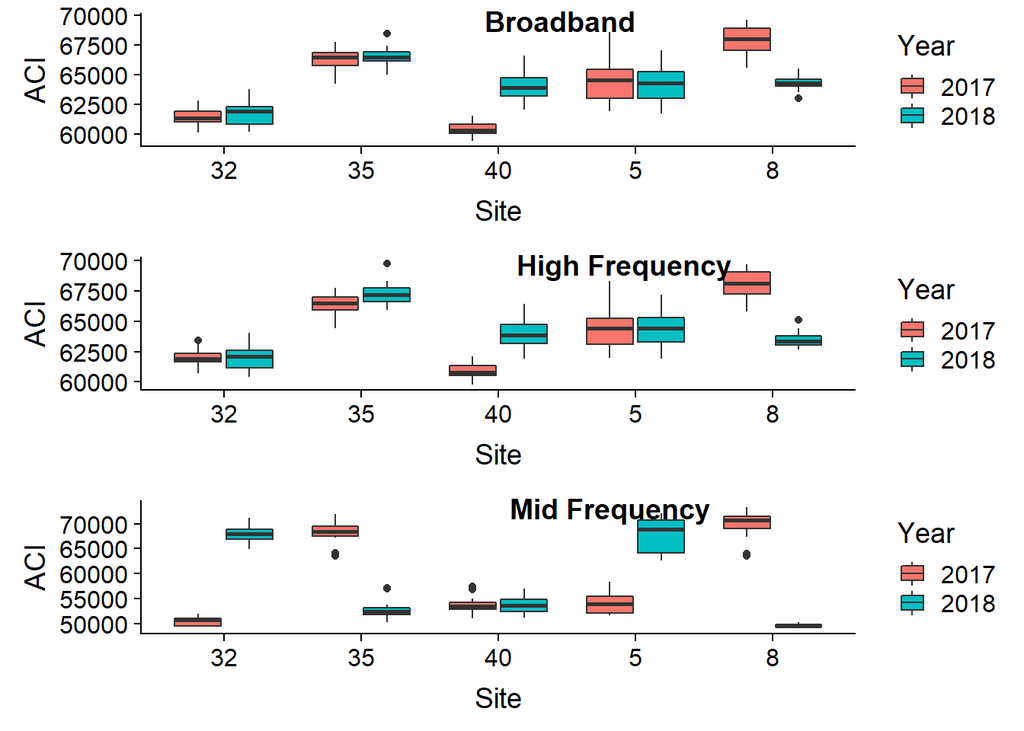

## Fish Sounds

### Total Knocks - Hourly

Total number of knocks is the sum total of a 5 minute recording from the beginning of each hour

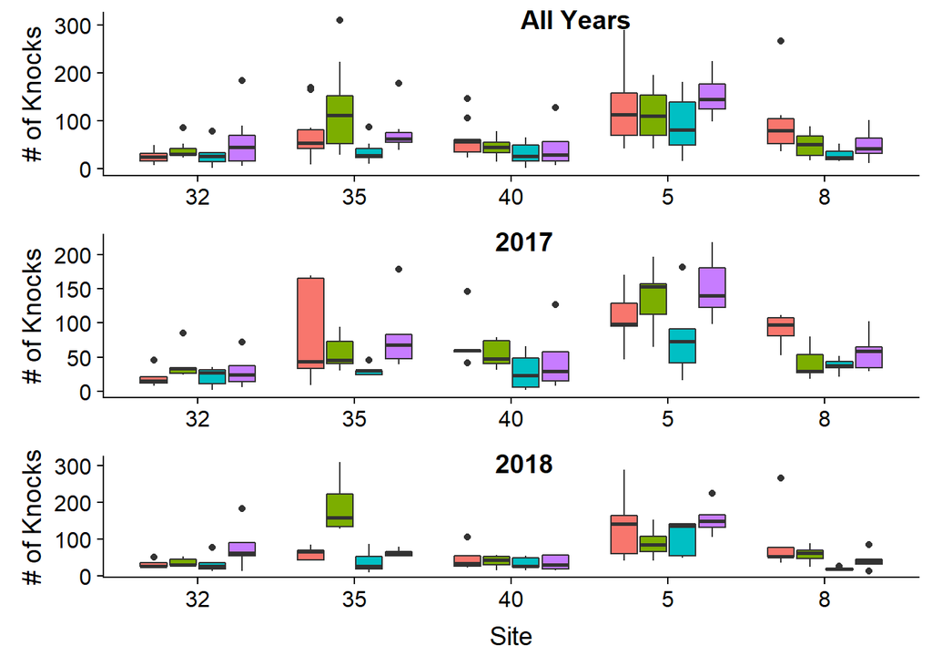

The 4 box plots in each site represent each time frame, 3 am, 9 am, 3 pm, and 9 pm - in that order

### Total Knocks - Daily

Total number of knocks summing all 4 samples to get a daily amount - to compare sites

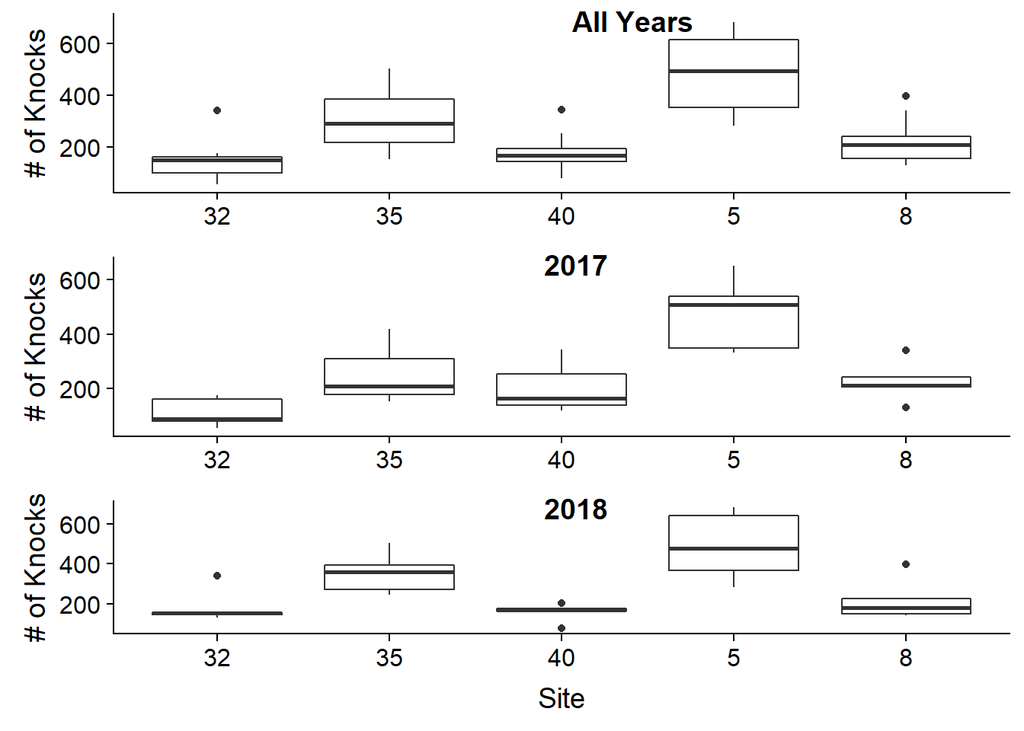

### Long Calls - Hourly

Total number of long calls is the sum total of a 5 minute recording from the beginning of each hour

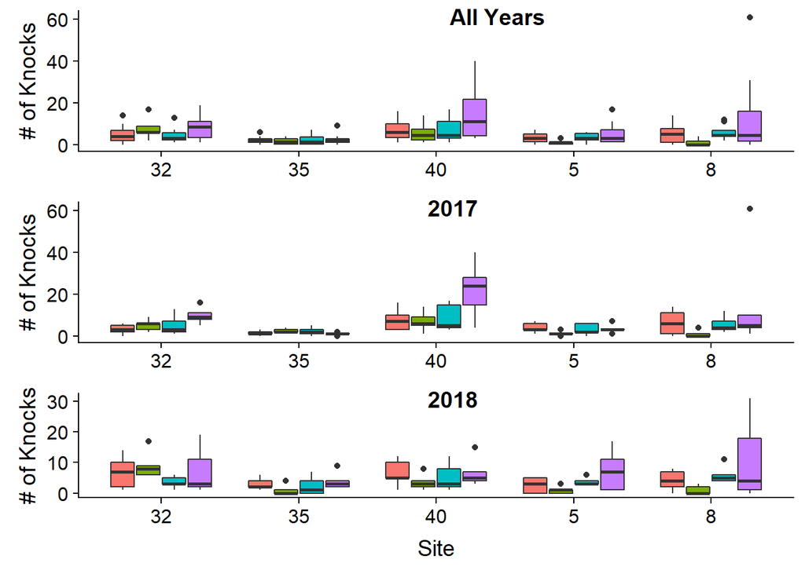

The 4 box plots in each site represent each time frame, 3 am, 9 am, 3 pm, and 9 pm - in that order

### Long Calls - Daily

Total long calls summing all 4 samples to get a daily amount - to compare sites

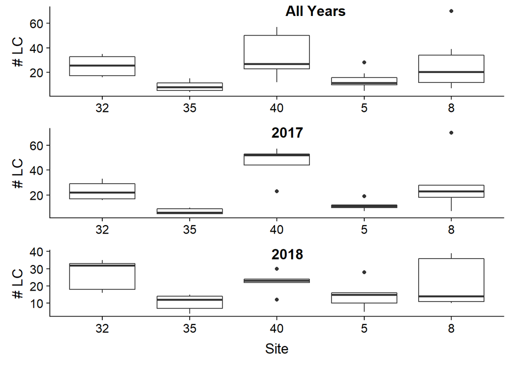

# Fish Abundance

**Fish Abundance** is the sum total of fish at that site at each observation that year, averages are made within sites within years when multiple UVC were made. However, all data has been plotted in addition to any averages to ensure that we know where the averages come from.

## Sum Fish abundance - summed to each UVC

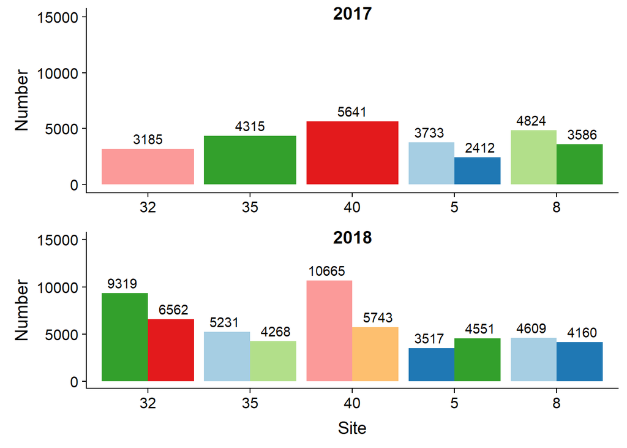

## Average Fish abundance

Fish Abundance - Averaged within years and then across years at all sites

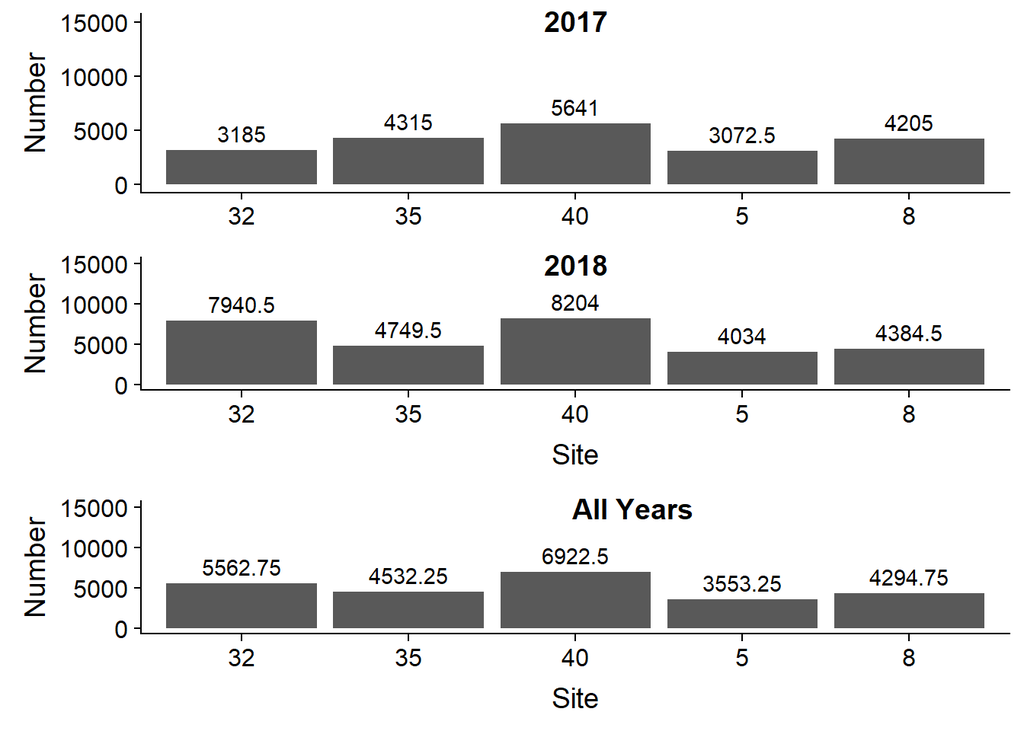

#Boat Visitations

**Boat Visitations** is the sum total number of boats detected visiting each site over their entire time deployed

*Note* this is ONLY the 2018 data

Boat Visitation Data for 2018 at each site

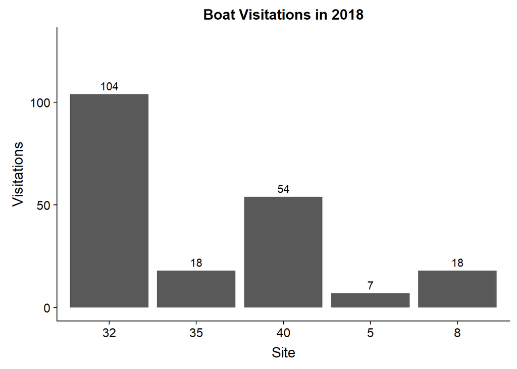

# Combined Model

**Combined Model** All variables are matched to the files that were used for Fish call counts (3:00, 9:00, 15:00, 21:00)

## Box Plots

```
##  [1] "st.id"         "Year"          "ACI_BB"        "ACI_HF"
##  [5] "ACI_Midrange"  "SPL_BB"        "SPL_HF"        "SPL_Midrange"
##  [9] "Hour"          "Site"          "Tot_Knocks"    "Num_L_calls"
## [13] "Num_Herbivory" "Date"          "Snaps"
```

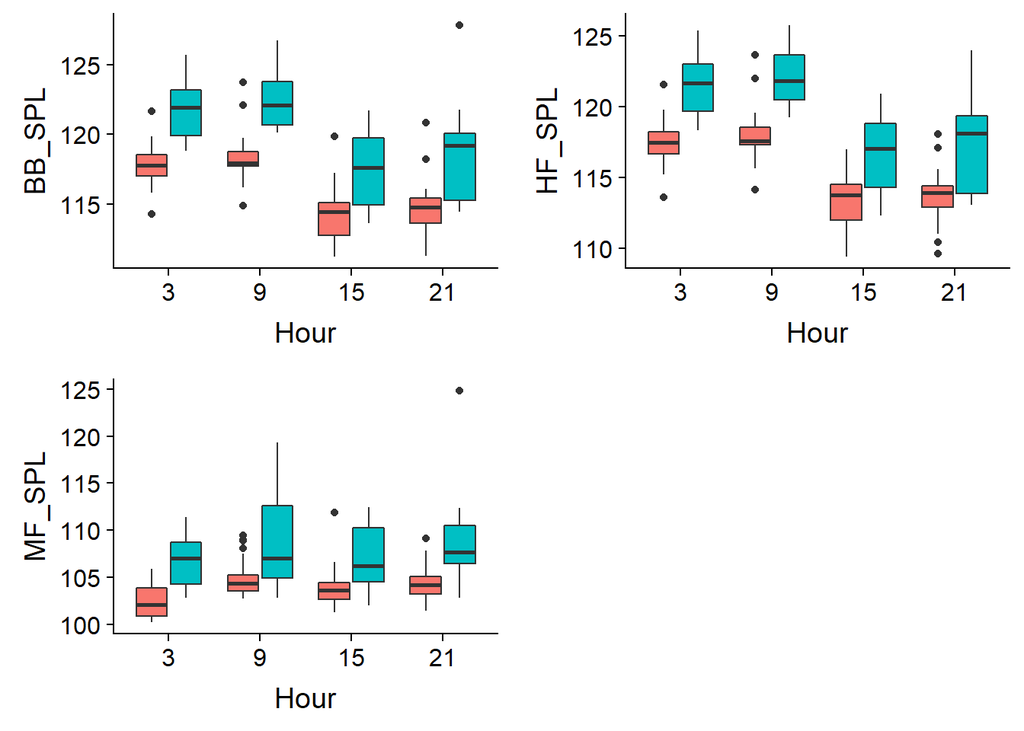

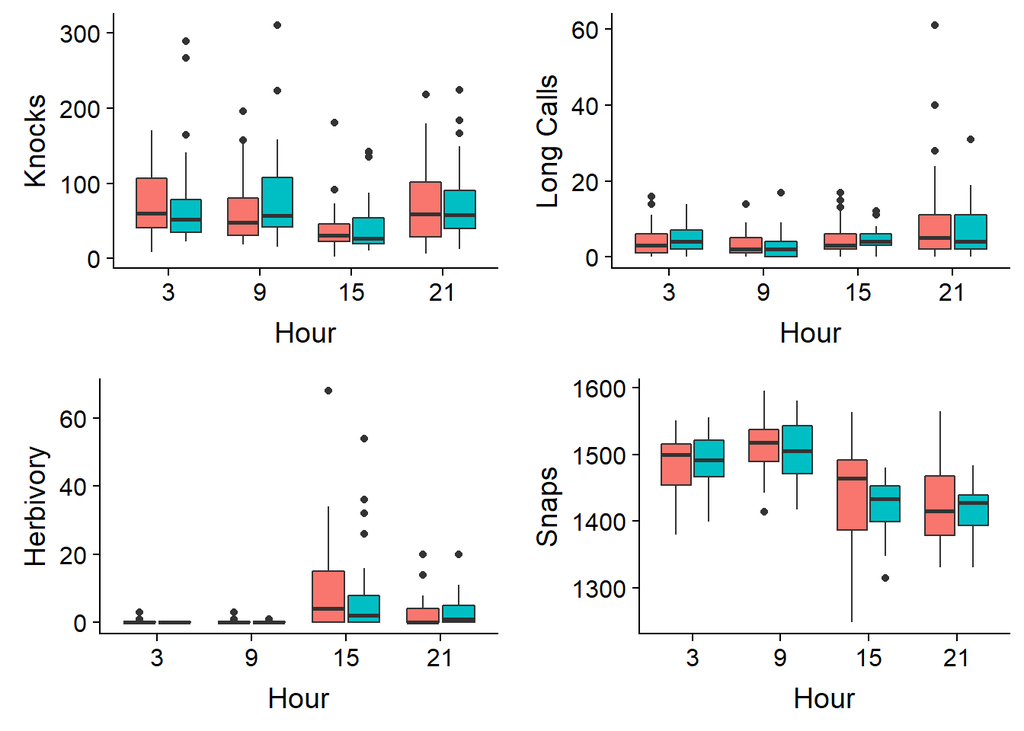

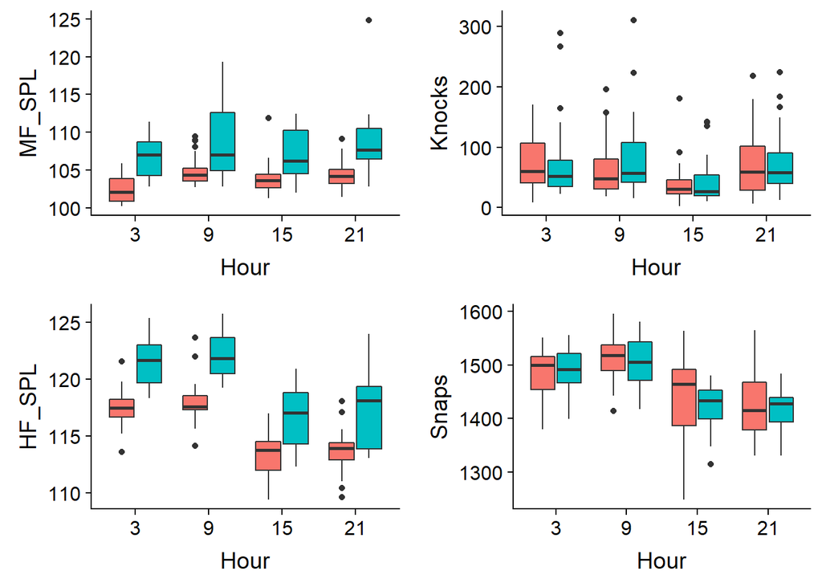

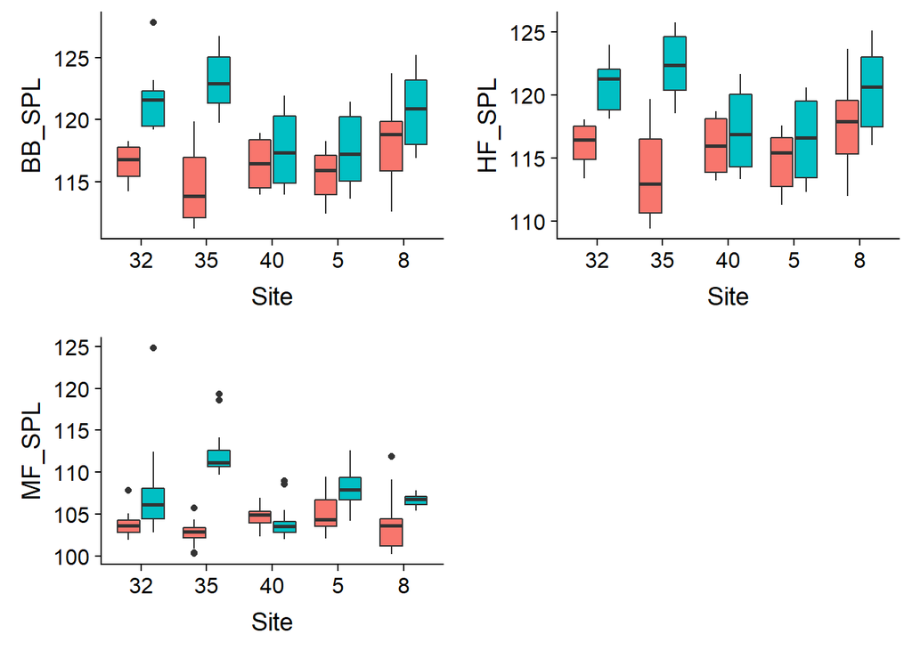

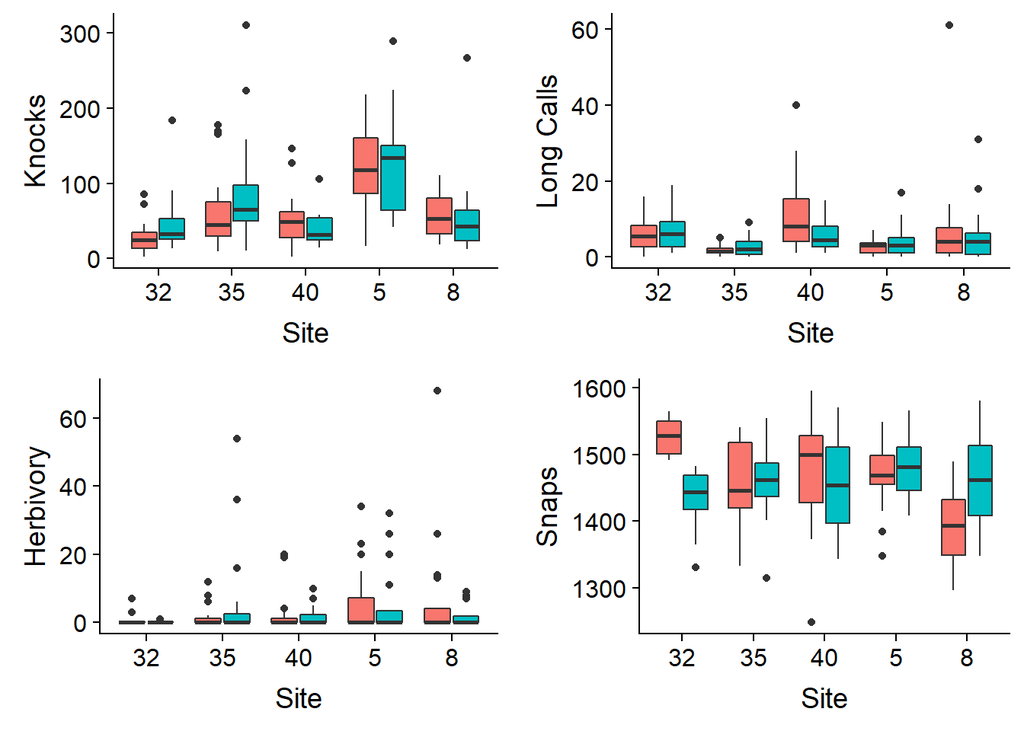

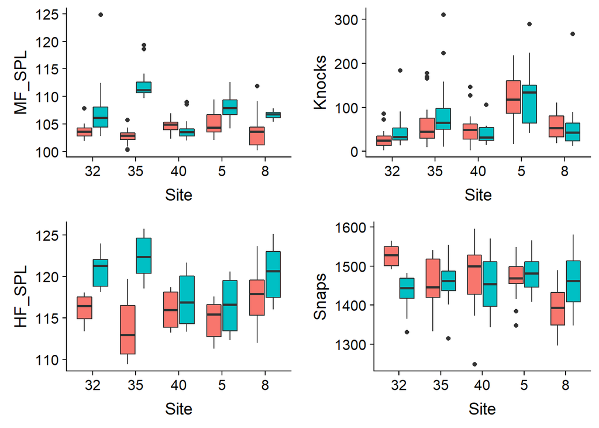

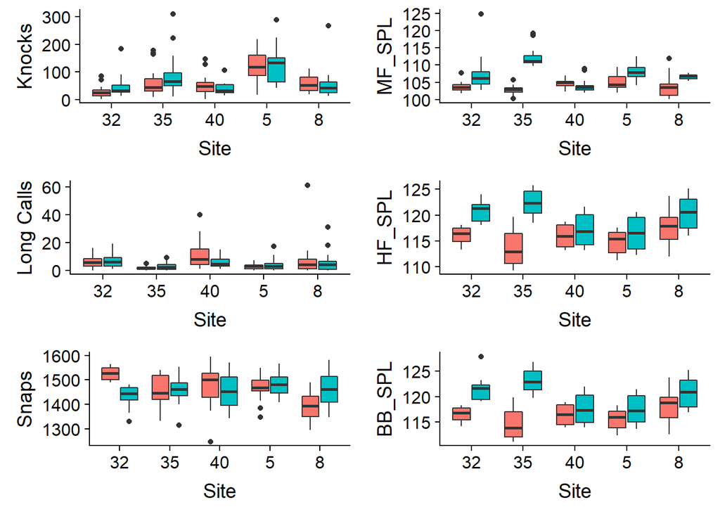

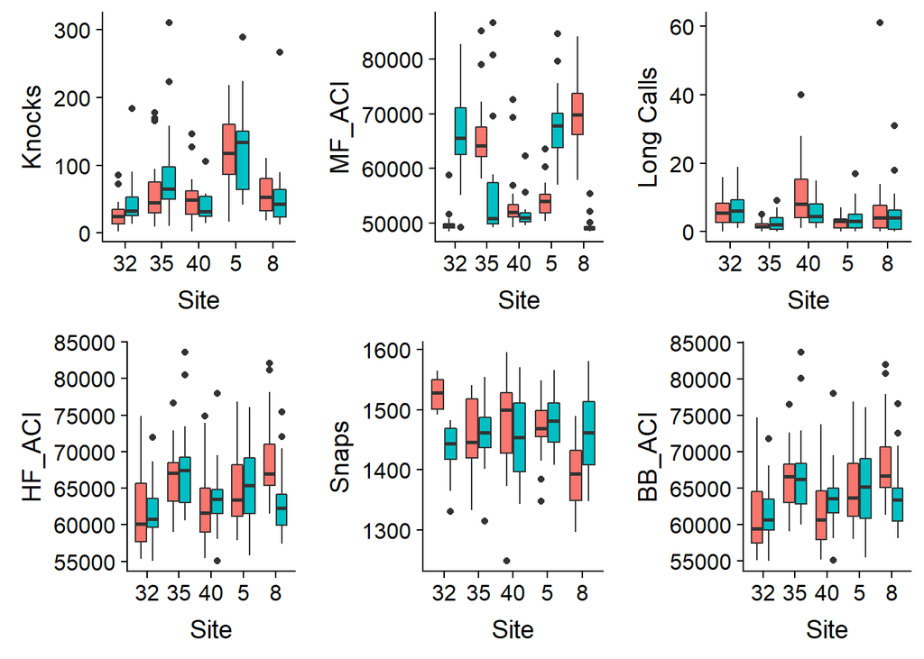

## Distributions

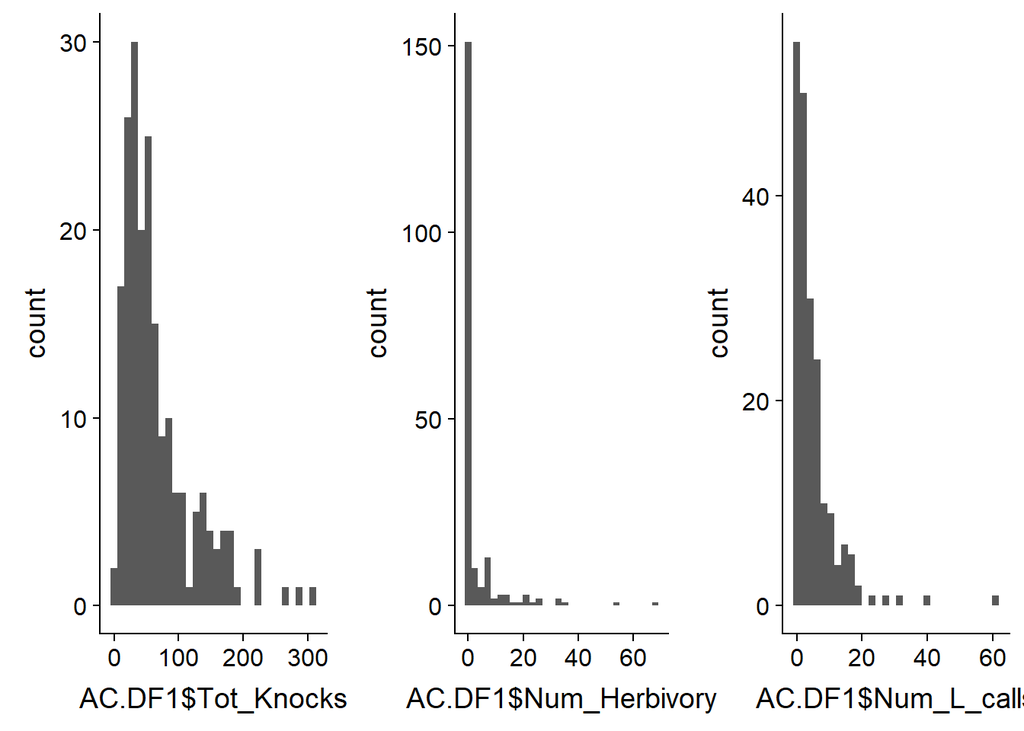

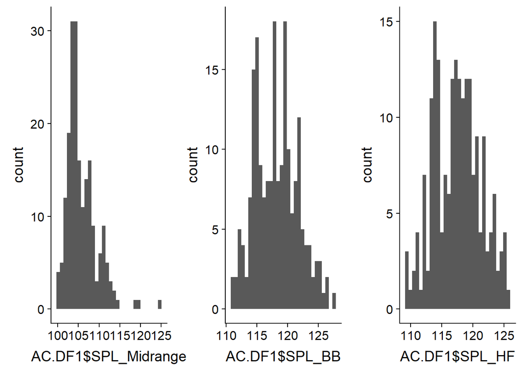

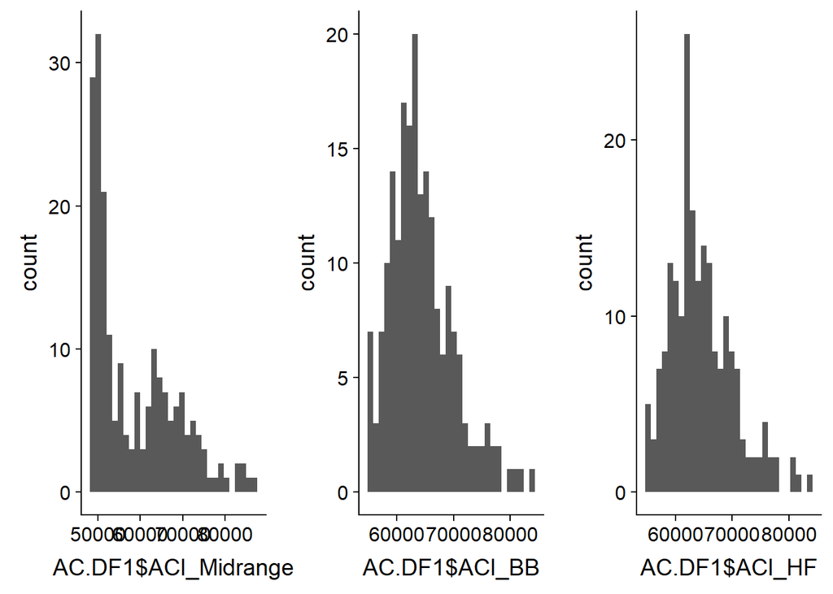

## Plotting regressions

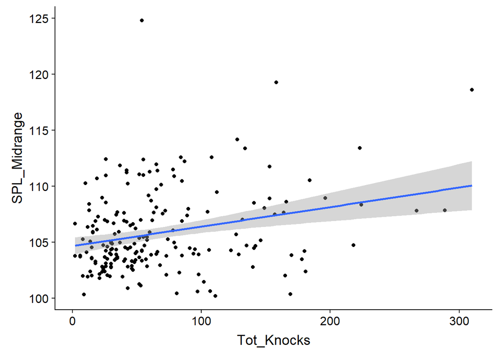

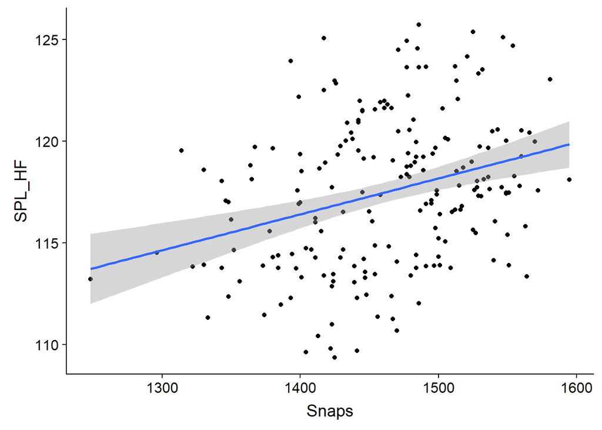

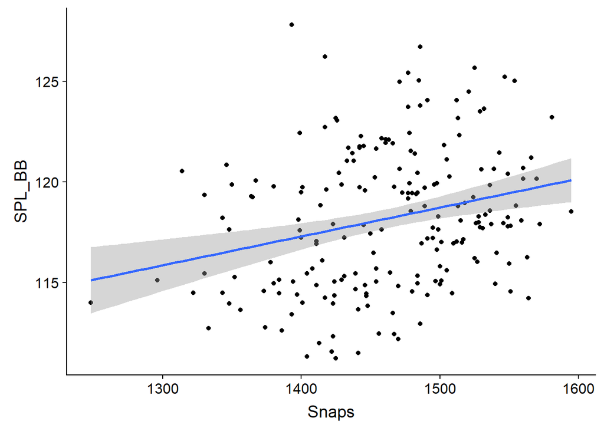

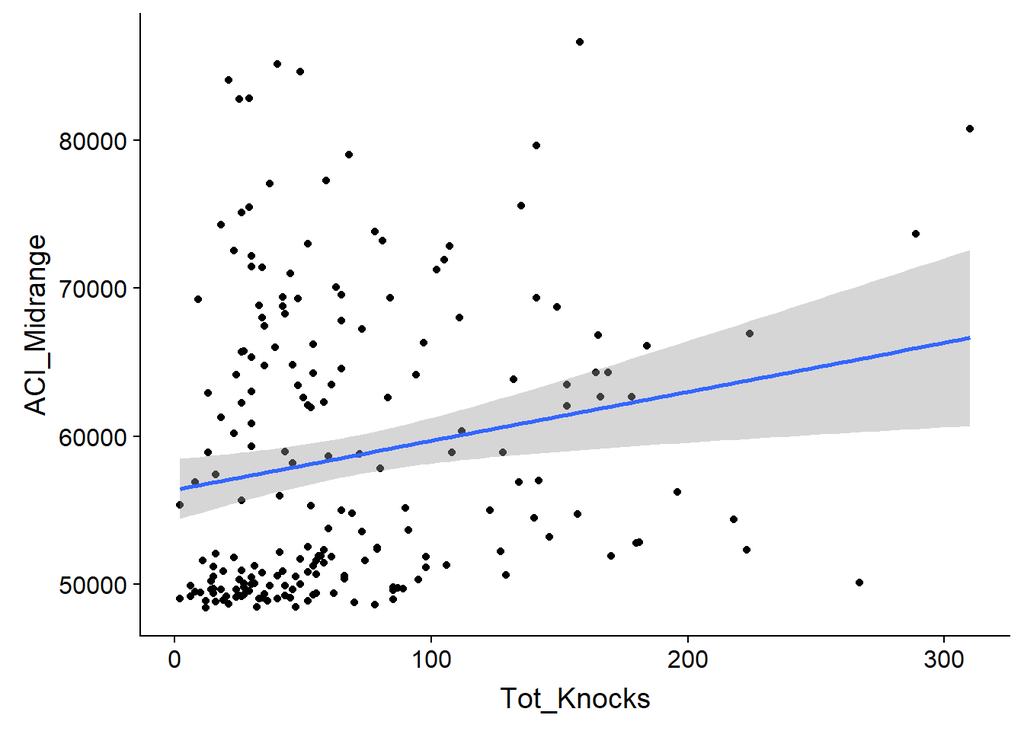